# PR11

201821479_황혜린

2018년 12월 1일

# 1 . dplyr 패키지

. dplyr은 Hadley Wickham이 만든 데이터 핸들링을 위한 패키지 . dplyr은 c++로 작성되어 기존 데이터핸들링 패키지보다 빠른 데이터조작이 가능 . 각종 데이터베어스 지원(MySQL, PostgreSQL, SQLite, BigQuery)수 . 기존R의 기본 문법과 프로그래밍능력을 바탕으로 데이터의 조작이 가능하지만 dplyr패키지를 활용하면 통일된 문법양식으로 데이터조작이 가능함 ·체인연산자를 지원함으로(%>%) 앞부분의 연산결과를 뒤에 오는 함수의 입력값으로 사용할 수 있음

## dplyr의 주요함수

filter; 지정한 조건식에 맞는 데이터 추출; subset select; 열의 추출; data[, c(“ Year”, “Month”)] mutate; 열 추가; transform arrange; 정렬; order, sort summarise; 집계; aggregate

# dplyr 실습 데이터 : nycflights13

```r
#install.packages("nycflights13")
library(nycflights13)
library(dplyr)
head(flights)
```

```
## # A tibble: 6 x 19
##    year month   day dep_time sched_dep_time dep_delay arr_time
##   <int> <int> <int>    <int>          <int>     <dbl>    <int>
## 1  2013     1     1      517            515         2      830
## 2  2013     1     1      533            529         4      850
## 3  2013     1     1      542            540         2      923
## 4  2013     1     1      544            545        -1     1004
## 5  2013     1     1      554            600        -6      812
## 6  2013     1     1      554            558        -4      740
## # ... with 12 more variables: sched_arr_time <int>, arr_delay <dbl>,
## #   carrier <chr>, flight <int>, tailnum <chr>, origin <chr>, dest <chr>,
## #   air_time <dbl>, distance <dbl>, hour <dbl>, minute <dbl>,
## #   time_hour <dttm>
```

# 1.1 dplyr의 filter함수

- 데이터에서 원하는 조건에 따라 행을 추출하는 함수
- filter( 데이터,조건1 | 조건2) : 조건1 또는 조건2 둘 중 한가지를 충족하는 데이터 추출
- filter( 데이터, 조건1 & 조건2) : 조건1과 조건2 모두 충족하는 데이터 추출 ·조건을 작성할 때 쉼표’,’는 AND, ‘|’는 OR와 같음

```r
filter(flights, month ==1 | day==1)
```

```
## # A tibble: 37,198 x 19
##     year month   day dep_time sched_dep_time dep_delay arr_time
##    <int> <int> <int>    <int>          <int>     <dbl>    <int>
##  1  2013     1     1      517            515         2      830
##  2  2013     1     1      533            529         4      850
##  3  2013     1     1      542            540         2      923
##  4  2013     1     1      544            545        -1     1004
##  5  2013     1     1      554            600        -6      812
##  6  2013     1     1      554            558        -4      740
##  7  2013     1     1      555            600        -5      913
##  8  2013     1     1      557            600        -3      709
##  9  2013     1     1      557            600        -3      838
## 10  2013     1     1      558            600        -2      753
## # ... with 37,188 more rows, and 12 more variables: sched_arr_time <int>,
## #   arr_delay <dbl>, carrier <chr>, flight <int>, tailnum <chr>,
## #   origin <chr>, dest <chr>, air_time <dbl>, distance <dbl>, hour <dbl>,
## #   minute <dbl>, time_hour <dttm>
```

```r
filter(flights, month ==1 , day==1)
```

```
## # A tibble: 842 x 19
##     year month   day dep_time sched_dep_time dep_delay arr_time
##    <int> <int> <int>    <int>          <int>     <dbl>    <int>
##  1  2013     1     1      517            515         2      830
##  2  2013     1     1      533            529         4      850
##  3  2013     1     1      542            540         2      923
##  4  2013     1     1      544            545        -1     1004
##  5  2013     1     1      554            600        -6      812
##  6  2013     1     1      554            558        -4      740
##  7  2013     1     1      555            600        -5      913
##  8  2013     1     1      557            600        -3      709
##  9  2013     1     1      557            600        -3      838
## 10  2013     1     1      558            600        -2      753
## # ... with 832 more rows, and 12 more variables: sched_arr_time <int>,
## #   arr_delay <dbl>, carrier <chr>, flight <int>, tailnum <chr>,
## #   origin <chr>, dest <chr>, air_time <dbl>, distance <dbl>, hour <dbl>,
## #   minute <dbl>, time_hour <dttm>
```

```r
filter(flights, month ==1 , day==1, year==2013)
```

```
## # A tibble: 842 x 19
##     year month   day dep_time sched_dep_time dep_delay arr_time
##    <int> <int> <int>    <int>          <int>     <dbl>    <int>
##  1  2013     1     1      517            515         2      830
##  2  2013     1     1      533            529         4      850
##  3  2013     1     1      542            540         2      923
##  4  2013     1     1      544            545        -1     1004
##  5  2013     1     1      554            600        -6      812
##  6  2013     1     1      554            558        -4      740
##  7  2013     1     1      555            600        -5      913
##  8  2013     1     1      557            600        -3      709
##  9  2013     1     1      557            600        -3      838
## 10  2013     1     1      558            600        -2      753
## # ... with 832 more rows, and 12 more variables: sched_arr_time <int>,
## #   arr_delay <dbl>, carrier <chr>, flight <int>, tailnum <chr>,
## #   origin <chr>, dest <chr>, air_time <dbl>, distance <dbl>, hour <dbl>,
## #   minute <dbl>, time_hour <dttm>
```

# 1.2 dplyr의 arrange함수

. 데이터를 원하는 조건에 따라 정렬해주는 함수 * arrange(데이터, 정렬기준컬럼1, 정렬기준컬럼2, 정렬기준컬럼3) . 내림차순으로 정렬 시 desc함수사용: arrange(데이터, desc(정렬기준컬럼1))

```r
arrange(flights, year, month ,day)
```

```
## # A tibble: 336,776 x 19
##     year month   day dep_time sched_dep_time dep_delay arr_time
##    <int> <int> <int>    <int>          <int>     <dbl>    <int>
##  1  2013     1     1      517            515         2      830
##  2  2013     1     1      533            529         4      850
##  3  2013     1     1      542            540         2      923
##  4  2013     1     1      544            545        -1     1004
##  5  2013     1     1      554            600        -6      812
##  6  2013     1     1      554            558        -4      740
##  7  2013     1     1      555            600        -5      913
##  8  2013     1     1      557            600        -3      709
##  9  2013     1     1      557            600        -3      838
## 10  2013     1     1      558            600        -2      753
## # ... with 336,766 more rows, and 12 more variables: sched_arr_time <int>,
## #   arr_delay <dbl>, carrier <chr>, flight <int>, tailnum <chr>,
## #   origin <chr>, dest <chr>, air_time <dbl>, distance <dbl>, hour <dbl>,
## #   minute <dbl>, time_hour <dttm>
```

```r
arrange(flights, desc(month))
```

```
## # A tibble: 336,776 x 19
##     year month   day dep_time sched_dep_time dep_delay arr_time
##    <int> <int> <int>    <int>          <int>     <dbl>    <int>
##  1  2013    12     1       13           2359        14      446
##  2  2013    12     1       17           2359        18      443
##  3  2013    12     1      453            500        -7      636
##  4  2013    12     1      520            515         5      749
##  5  2013    12     1      536            540        -4      845
##  6  2013    12     1      540            550       -10     1005
##  7  2013    12     1      541            545        -4      734
##  8  2013    12     1      546            545         1      826
##  9  2013    12     1      549            600       -11      648
## 10  2013    12     1      550            600       -10      825
## # ... with 336,766 more rows, and 12 more variables: sched_arr_time <int>,
## #   arr_delay <dbl>, carrier <chr>, flight <int>, tailnum <chr>,
## #   origin <chr>, dest <chr>, air_time <dbl>, distance <dbl>, hour <dbl>,
## #   minute <dbl>, time_hour <dttm>
```

# 1.3 dplyr의 select함수

- select함수는 원하는 열(column)을 추출
- select(데이터, 컬럼1, 컬럼2, 컬럼3)
- select(데이터, 컬럼1:컬럼3) -컬럼명을 변경할 수 있음

```r
select(flights, year, month, day)
```

```
## # A tibble: 336,776 x 3
##     year month   day
##    <int> <int> <int>
##  1  2013     1     1
##  2  2013     1     1
##  3  2013     1     1
##  4  2013     1     1
##  5  2013     1     1
##  6  2013     1     1
##  7  2013     1     1
##  8  2013     1     1
##  9  2013     1     1
## 10  2013     1     1
## # ... with 336,766 more rows
```

```r
select(flights, year:day)
```

```
## # A tibble: 336,776 x 3
##     year month   day
##    <int> <int> <int>
##  1  2013     1     1
##  2  2013     1     1
##  3  2013     1     1
##  4  2013     1     1
##  5  2013     1     1
##  6  2013     1     1
##  7  2013     1     1
##  8  2013     1     1
##  9  2013     1     1
## 10  2013     1     1
## # ... with 336,766 more rows
```

```r
select(flights, -(year:day))
```

```
## # A tibble: 336,776 x 16
##    dep_time sched_dep_time dep_delay arr_time sched_arr_time arr_delay
##       <int>          <int>     <dbl>    <int>          <int>     <dbl>
##  1      517            515         2      830            819        11
##  2      533            529         4      850            830        20
##  3      542            540         2      923            850        33
##  4      544            545        -1     1004           1022       -18
##  5      554            600        -6      812            837       -25
##  6      554            558        -4      740            728        12
##  7      555            600        -5      913            854        19
##  8      557            600        -3      709            723       -14
##  9      557            600        -3      838            846        -8
## 10      558            600        -2      753            745         8
## # ... with 336,766 more rows, and 10 more variables: carrier <chr>,
## #   flight <int>, tailnum <chr>, origin <chr>, dest <chr>, air_time <dbl>,
## #   distance <dbl>, hour <dbl>, minute <dbl>, time_hour <dttm>
```

# 1.4 dplyr의 distinct함수

- 중복항목을 제외한 데이터를 확인 할 수 있음(unique함수와 동일) -distinct(데이터, 컬럼명)

```r
distinct(select(flights, tailnum))
```

```
## # A tibble: 4,044 x 1
##    tailnum
##    <chr>
##  1 N14228
##  2 N24211
##  3 N619AA
##  4 N804JB
##  5 N668DN
##  6 N39463
##  7 N516JB
##  8 N829AS
##  9 N593JB
## 10 N3ALAA
## # ... with 4,034 more rows
```

```r
distinct(select(flights, origin, dest))
```

```
## # A tibble: 224 x 2
##    origin dest
##    <chr>  <chr>
##  1 EWR    IAH
##  2 LGA    IAH
##  3 JFK    MIA
##  4 JFK    BQN
##  5 LGA    ATL
##  6 EWR    ORD
##  7 EWR    FLL
##  8 LGA    IAD
##  9 JFK    MCO
## 10 LGA    ORD
## # ... with 214 more rows
```

# 1.5 dplyr의 mutate함수

-기존 데이티 프레임에 새로운 열을 추가해줌 * 데이터 프레임 내의 변수들을 활용해 새로운 변수를 만들 때 효과적임 ·새로 생성한 변수를 해당 함수내에서 바로 활용이 가능

```r
mutate(flights, gain <- arr_delay - dep_delay)
```

```
## # A tibble: 336,776 x 20
##     year month   day dep_time sched_dep_time dep_delay arr_time
##    <int> <int> <int>    <int>          <int>     <dbl>    <int>
##  1  2013     1     1      517            515         2      830
##  2  2013     1     1      533            529         4      850
##  3  2013     1     1      542            540         2      923
##  4  2013     1     1      544            545        -1     1004
##  5  2013     1     1      554            600        -6      812
##  6  2013     1     1      554            558        -4      740
##  7  2013     1     1      555            600        -5      913
##  8  2013     1     1      557            600        -3      709
##  9  2013     1     1      557            600        -3      838
## 10  2013     1     1      558            600        -2      753
## # ... with 336,766 more rows, and 13 more variables: sched_arr_time <int>,
## #   arr_delay <dbl>, carrier <chr>, flight <int>, tailnum <chr>,
## #   origin <chr>, dest <chr>, air_time <dbl>, distance <dbl>, hour <dbl>,
## #   minute <dbl>, time_hour <dttm>, `gain <- arr_delay - dep_delay` <dbl>
```

```r
mutate(flights, gain=arr_delay - dep_delay, gain_per_hour=gain/(air_time/60))
```

```
## # A tibble: 336,776 x 21
##     year month   day dep_time sched_dep_time dep_delay arr_time
##    <int> <int> <int>    <int>          <int>     <dbl>    <int>
##  1  2013     1     1      517            515         2      830
##  2  2013     1     1      533            529         4      850
##  3  2013     1     1      542            540         2      923
##  4  2013     1     1      544            545        -1     1004
##  5  2013     1     1      554            600        -6      812
##  6  2013     1     1      554            558        -4      740
##  7  2013     1     1      555            600        -5      913
##  8  2013     1     1      557            600        -3      709
##  9  2013     1     1      557            600        -3      838
## 10  2013     1     1      558            600        -2      753
## # ... with 336,766 more rows, and 14 more variables: sched_arr_time <int>,
## #   arr_delay <dbl>, carrier <chr>, flight <int>, tailnum <chr>,
## #   origin <chr>, dest <chr>, air_time <dbl>, distance <dbl>, hour <dbl>,
## #   minute <dbl>, time_hour <dttm>, gain <dbl>, gain_per_hour <dbl>
```

# 1.6 dplyr의 summarise함수

-mean(), sd(), var(), median()함수를 활용해 기술통계량을 확인 -결과를 데이터프레임으로 반환함

```r
summarise(flights, delay = mean(dep_delay, na.rm = T))
```

```
## # A tibble: 1 x 1
##   delay
##   <dbl>
## 1  12.6
```

# 1.7 dplyr의 group_by()함수

- 변수의 레벨에 따라 자료를 그룹화 해줌 *그룹에 따른 수치자료를 산출하고 싶을 때 편리함
- summarise함수와 함께 사용시 aggregate함수와 같은 기능
- ex)직급에 따른 평균 연봉과 사용가능한 연차일수(휴가)를 구하고 싶을 때!

```r
#비행기별로 그룹 만들기

by_tailnum = group_by(flights, tailnum)

delay = summarise(by_tailnum, count=n(), dist=mean(distance, na.rm = T), delay=mean(arr_delay, na.rm = T))


#횟수가 20이상, 거리가 2000이하인 비행기만 추출

delay=filter(delay, count > 20, dist < 2000)
dist
```

[output not shown]

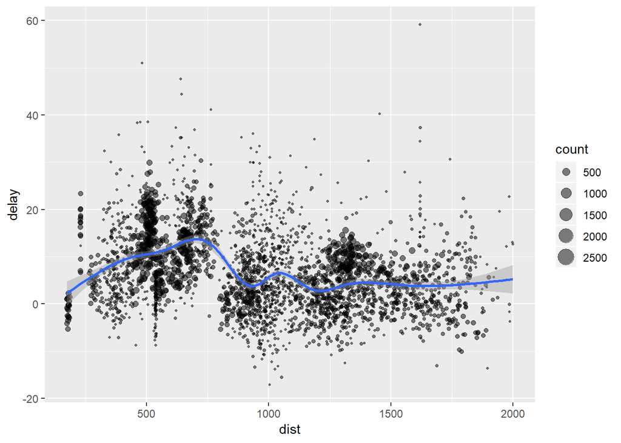

```r
#위에서 만든 delay데이터로 시각화

library(ggplot2)

ggplot(delay, aes(dist, delay)) +
  geom_point(aes(size = count), alpha = 1/2) +
  geom_smooth() +
  scale_size_area()
```

# 1.8 dplyr의 Chain 연산

-여러단계의 함수나 연산을 연결하여 한번에 수행할 때 사용 * 옆의 함수의 결과는 바로 뒤에 오는 함수의 입력값이 됨 * 데이터를 여러 객체에 할당하지 않아도 되기때문에 메모리 관리에 유리함

## 체인연산 사용하지 않을 때

```r
a1= group_by(flights, year, month, day)
a2= select(a1, year:day, arr_delay)
a3= summarise(a2, arr=mean(arr_delay, na.rm=T))
a4= filter(a3, arr >30)
a4
```

```
## # A tibble: 42 x 4
## # Groups:   year, month [11]
##     year month   day   arr
##    <int> <int> <int> <dbl>
##  1  2013     1    16  34.2
##  2  2013     1    31  32.6
##  3  2013     2    11  36.3
##  4  2013     2    27  31.3
##  5  2013     3     8  85.9
##  6  2013     3    18  41.3
##  7  2013     4    10  38.4
##  8  2013     4    12  36.0
##  9  2013     4    18  36.0
## 10  2013     4    19  47.9
## # ... with 32 more rows
```

## 체인연산 사용했을 때

```r
flights %>% group_by(year, month, day) %>% select(arr_delay) %>% summarise(arr = mean(arr_delay, na.rm=T)) %>% filter(arr>30)
```

```
## # A tibble: 42 x 4
## # Groups:   year, month [11]
##     year month   day   arr
##    <int> <int> <int> <dbl>
##  1  2013     1    16  34.2
##  2  2013     1    31  32.6
##  3  2013     2    11  36.3
##  4  2013     2    27  31.3
##  5  2013     3     8  85.9
##  6  2013     3    18  41.3
##  7  2013     4    10  38.4
##  8  2013     4    12  36.0
##  9  2013     4    18  36.0
## 10  2013     4    19  47.9
## # ... with 32 more rows
```

# 1.9 dplyr의 join함수

-join(x, y) 또는 join(x, y, by=”기준열”) 형태 -조인의 기준이 되는 단일 컬럼이 존재하는 경우 별도 by인수를 지정하지 않아도 됨

```r
#join 실습 데이터 생성
#install.packages("readr")

library(readr)
superheroes <- "
name, alignment, gender, publisher
Magneto, bad, male, Marvel
Storm, good, female, Marvel
Mystique, bad, female, Marvel
Betman, good, male, DC
Joker, bad, male, DC
Catwoman, bad, female, DC
Heilboy, good, male, Dark Horse Comics
"

publishers <- "
Publisher, yr_founded
DC, 1934
Marvel, 1939
Image, 1992
"
superheroes <- read_csv(superheroes, trim_ws=T)
publishers <- read_csv(publishers, trim_ws=T)
```

```r
library(dplyr)
#inner_join(superheroes, publishers)
#left_join(superheroes, publishers)
#full_join(superheroes, publishers)
#anti_join(superheroes, publishers)
#semi_join(superheroes, publishers)

#ㅠㅠ계속 에러가 떠서 주석처리합니다
```

# join 예제

-raw.csv는 국회의원 별 의원비 지출내역 -join.csv는 국회의원 명단 -두 데이터를 조인하기 위해서는 raw.csv의 데이터를 -aggregate 또는 summarize함수를 사용해 요약해야 함 * 이름을 기준으로 join을 할 것

```r
#의원비 지출이 가장 많은 10명의 직업과 학력을 확인
#데이터 로딩

setwd("C:/Users/hyere/Desktop/R/CSVdata")
raw_data=read.csv("raw.csv")
join_data = read.csv("join.csv")
head(raw_data)
```

```
##   X total_num cong_num   name    party          region       date
## 1 1    217616      309 현영희   무소속            비례 2014-01-03
## 2 2    217617      309 현영희   무소속            비례 2014-01-03
## 3 3    217618      309 현영희   무소속            비례 2014-01-03
## 4 4    217619      309 현영희   무소속            비례 2014-01-03
## 5 5    217620      309 현영희   무소속            비례 2014-01-05
## 6 6    221930        1 강기윤 새누리당 경남 창원성산구 2014-01-02
##                 item expense            store    category region2
## 1             항공료   68600         대한항공   교통-항공    비례
## 2 전문가 간담회 식대   78000     카페모차르트 간담회-식대    비례
## 3             항공료   97100         대한항공   교통-항공    비례
## 4             유류비  138000     예스제이오일   차량-주유    비례
## 5             유류비   60000 과정로셀프주유소   차량-주유    비례
## 6         우편발송료    3070       창원우체국   홍보-우편    경남
##        date2 date_month
## 1 2014-01-03        1월
## 2 2014-01-03        1월
## 3 2014-01-03        1월
## 4 2014-01-03        1월
## 5 2014-01-05        1월
## 6 2014-01-02        1월
```

```r
head(join_data)
```

```
##     X region district    party   name gender      birth
## 1  94   비례 비례대표 새누리당 민현주     여 1969-07-23
## 2 135   비례 비례대표 새누리당 신경림     여 1954-03-22
## 3 235   경기   하남시 새누리당 이현재     남 1949-04-25
## 4 294   인천   남구갑 새누리당 홍일표     남 1956-02-11
## 5 185   충북   충주시 새누리당 윤진식     남 1946-03-04
## 6 131   비례 비례대표 새누리당 손인춘     여 1959-05-13
##                                     job
## 1 경기대학교 일반대학원 직업학과 조교수
## 2       이화여자대학교 건강과학대학학장
## 3                                정당인
## 4                              국회의원
## 5                              국회의원
## 6                   (주)인성내츄럴 사장
##                                                                     achievement
```

[output cut: 20 more lines]

```r
#조인할 데이터 추출
expense=aggregate(expense~name+party, data=raw_data, FUN=sum)
job_school=select(join_data, name, job, achievement)
#조인
joined =inner_join(expense, job_school, by='name')
joined = joined[order(joined$expense, decreasing=T),]
joined[1:10,]
```

```
##       name    party   expense                           job
## 91  이명수 새누리당 446913569                      국회의원
## 17  김상민 새누리당 402282444 대학생자원봉사단 V원정대 대표
## 126 조원진 새누리당 392767643                      국회의원
## 58  서상기 새누리당 351375323                      국회의원
## 277 이상규 통합진보 346551904                        정당인
## 271 심상정 진보정의 336436592                        정당인
## 187 박지원   새정치 331136715                      국회의원
## 120 정병국 새누리당 330634706                      국회의원
## 215 유성엽   새정치 330615390                      국회의원
## 233 이종걸   새정치 323533338                        변호사
##                                              achievement
## 91            성균관대 대학원 졸업(행정학과 행정학 박사)
## 17                                 아주대학교 사학과졸업
## 126 영남대학교 행정대학원 정책분석학과 졸업(행정학 석사)
## 58              美드렉셀대학교 공학박사(1972.09~1976.06)
## 277                    서울대학교 법과대학 공법학과 졸업
## 271                           서울대학교 사회교육과 졸업
## 187                                   단국대 상학과 졸업
## 120                성균관 대학교 대학원 졸업(정치학박사)
## 215                서울대학교 사회과학대학 외교학과 졸업
## 233                    서울대학교 법과대학 공법학과 졸업
```

# 2. reshape2

- reshape2는 wide와 long포맷으로 쉽게 데이터를 변환해줌 . melt 함수는 wide 포맷 데이터를 long 포맷으로 변환해주는 함수 (tidyr::gather와 유사)
- cast는 long 포맷 데이터를 wide 포맷으로 변환해주는 함수 (tidyr::spread와 유사)

# 2.1. wide 포맷 데이터를 long 포맷으로 전환하기: melt 함수

- R에 내장되어 있는 airquality라는 데이터셋 사용
- 먼저 데이터셋을 쉽게 변경하기 위해 각 열의 이름을 전부 소문자로 변경

```r
library(reshape2)
names(airquality) <- tolower(names(airquality))
head(airquality)
```

```
##   ozone solar.r wind temp month day
## 1    41     190  7.4   67     5   1
## 2    36     118  8.0   72     5   2
## 3    12     149 12.6   74     5   3
## 4    18     313 11.5   62     5   4
## 5    NA      NA 14.3   56     5   5
## 6    28      NA 14.9   66     5   6
```

```r
#일단위 오존량, 태양 복사열, 풍속 그리고 온도를 알고 싶습니다.
#이럴 때 “ID variable”을 사용하면 설정을 해 줄 수 있습니다.

aql <- melt(airquality, id.vars=c("month", "day"))
head(aql)
```

```
##   month day variable value
## 1     5   1    ozone    41
## 2     5   2    ozone    36
## 3     5   3    ozone    12
## 4     5   4    ozone    18
## 5     5   5    ozone    NA
## 6     5   6    ozone    28
```

```r
#long 포맷 데이터의 열 이름 지정
aql <- melt(airquality, id.vars=c("month", "day"), variable.names=("climate_variable"), value.name = ("climate_value"))
head(aql)
```

```
##   month day variable climate_value
## 1     5   1    ozone            41
## 2     5   2    ozone            36
## 3     5   3    ozone            12
## 4     5   4    ozone            18
## 5     5   5    ozone            NA
## 6     5   6    ozone            28
```

## melt 연습하기

```r
#Chickweight데이터(R 기본 내장 데이터셋)

head(ChickWeight)
```

```
## Grouped Data: weight ~ Time | Chick
##   weight Time Chick Diet
## 1     42    0     1    1
## 2     51    2     1    1
## 3     59    4     1    1
## 4     64    6     1    1
## 5     76    8     1    1
## 6     93   10     1    1
```

```r
#melt를 사용하여 ID variable을 time,chick,diet를 주고 weigh를value로 주는 chick-m이란 변수 만들기
```

[output not shown]